[figure not shown]

### Step 5. Statistics

The field of meta-statistics is a rich and fascinating set of tools, literature, and discussions. Herein, we direct the practioner to several extremely useful resources associated with this specific topic. To become competent with an open science worflow for meta-analysis, a detailed knowledge of the statistics is of course preferable but not critical. A viable philosphy for the appropriate application of meta-statistics is best defined by the following set of assumptions. (1) Know thy ‘derived’ data and the limitations of the set of research summarized. This informs the statistics. (2) All statistics are a tool and a means to end - not the end. (3) The formal application of statistics to data from the t-test to the most advanced analysis you can imagine is an exercise in model fitting. A model is a representation of an idea. Period. Statistics are thus one mechanism that provides the evidence-based synthesis researcher with a tool to represent the ideas that stimulated the synthesis. No more, no less. (4) Description of the patterns across a set of studies or datasets is a powerful discovery tool. Do not underestimate the power of… this side of synthesis (or the force). (5) A meta-analysis is not an experiment and does not directly test a hypothesis. It can provide quantitative evidence and probabilities associed with strength of evidence, differences, and consistency and establish a weighted description of the efficacy of different interventions very broadly. (6) Even more profoundly and not uncommonly, meta-analysis as an open science synthesis research tool can highlight research gaps. (7) An ideal starting point is to assume that simple meta-statistics are akin to an ANOVA but for a population of relatively-independent singular data points. This constellation of points can be modeled as fixed or random. More advanced meta-analyses or differences in the type of data simply shift the perspective from ANOVA to reframing as a GLM (same thing) but then slides along to GLMM and this broader family of thinking. Not dissimilar from primary data statistical thinking. The difference is that we do not have one ‘data’ but ‘many representative data’. Very Seussian. There are four primary processes associated with the statistics step of an open science approach to meta-analysis.

**Key meta-statistical processes** (a) calculate effect size(s)  
(b) visualize effect size data (typically a forest plot)  
(c) fit a meta-statistical model  
(d) explore heterogeneity and bias

### Open science product

A [forest plot](https://en.wikipedia.org/wiki/Forest_plot) is typically the primary open science research product and assumed to be included in some form within the synthesis publication as a key figure. Ideally, contemporary open science researcher should also publicly and openly disseminate the statistical workflow - i.e. share R code illuminating this element of the workflow and ensuring the meta-statistics like the search and sort processes are reproducible.

### Case study

The book [Meta-analysis with R](http://www.springer.com/us/book/9783319214153) provides an extensive set of worked examples including data and R code. The packages ‘meta’ and ‘metafor’ are also bundled with sample datasets. To promote continuity, here are some of the examples from previous steps provided as an indication of the ease of meta-analysis with R. It is not the implementation of the code that limits us in doing meta-analyses but the access to data. The package meta (and metafor) provide most meta-statistical options as functions or arguments within broader functions for all the data differences and data structures that an environmental or natural science reseacher will encounter.

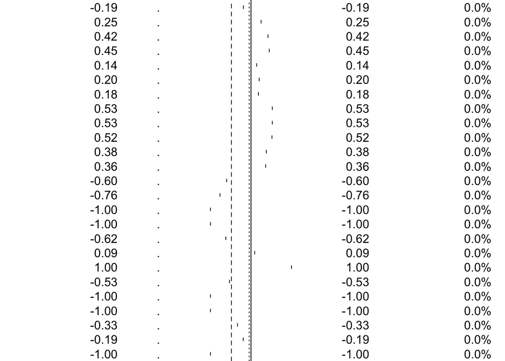

```r
#library setup####
library(tidyverse)
pkgs <- c("mada", "meta", "metafor", "metasens", "mvmeta", "netmeta", "rmeta", "ellipse") #recommended install for almost every meta-challenge you will encounter, most parsonimous install is 'meta'
#install.packages(pkgs, repos="http://cran.rstudio.com/") #run once per machine not per instance

#effect sizes####
#if reported within primary studies, you could be ready to go already. If not, the package meta provides a wide variety of standard effect size measures provided you have the data.
cushions <-read_csv("data/cushion-data.csv") #dataset that captured effect sizes directly from plant interaction studies
library(meta)
m <- metagen(cushions$Rii, cushions$`Var Rii`)
forest(m)
```

```r
m
```

```
##                         95%-CI %W(fixed) %W(random)
## 1   -1.0000 [-1.0980; -0.9020]       0.0        1.7
## 2   -1.0000 [-1.0980; -0.9020]       0.0        1.7
## 3    0.1568 [ 0.0588;  0.2548]       0.0        1.7
## 4    0.0685 [-0.9786;  1.1156]       0.0        1.0
## 5   -0.4595 [-1.0841;  0.1652]       0.0        1.4
## 6   -0.5992 [-1.3153;  0.1168]       0.0        1.3
## 7    0.0000 [-0.4868;  0.4868]       0.0        1.5
## 8   -1.0000 [-1.3389; -0.6611]       0.0        1.6
## 9   -0.3846 [-0.6481; -0.1211]       0.0        1.6
## 10   0.6379 [ 0.5399;  0.7359]       0.0        1.7
## 11  -0.0682 [-0.1662;  0.0298]       0.0        1.7
## 12   1.0000 [ 0.9020;  1.0980]       0.0        1.7
## 13  -1.0000 [-1.0980; -0.9020]       0.0        1.7
## 14   0.3593 [ 0.3589;  0.3597]       0.0        1.7
```

[output cut: 677 more lines]

### Exercise

Work with your existing synthesis dataframe. Begin with data viz. Generate a forest plot. Fit one meta-statistical model. Examine heterogeneity. List potential sources of biases that are always present in a higher-order synthesis.

### Additional resources

[Meta-analysis with R](http://www.springer.com/us/book/9783319214153) is a stunning resource.

The [meta](https://cran.r-project.org/web/packages/meta/index.html) vignette is an excellent starting point for an overview of the functions and data in this package.

The [metafor](https://cran.r-project.org/web/packages/metafor/index.html) resources provided by CRAN are similarly useful.

There are many ‘how-to’ papers published for meta-analysis. [Here](http://onlinelibrary.wiley.com/wol1/doi/10.1348/000711010X502733/full) is nice example.